# 一、语料库

语料库是我们要分析的所有文档的集合。

[语料库下载github备份](https://github.com/nltk/nltk_data)

# 二、中文分词

## 2.1 概念：

中文分词（Chinese Word Segmentation）：将一个汉字序列切分成一个一个单独的词。

停用词（Stop Words）：

数据处理时，需要过滤掉某些字或词

## 2.2 安装Jieba分词包：

最简单的方法是用CMD直接安装：输入pip install jieba。

### jieba库的使用详解

[jieba库的使用详解](https://github.com/fxsjy/jieba)

### jieba库的API 如下

#### API用于描述模块中提供的函数的功能和调用方法,因此阅读并且理解所使用的package的API很有必要。

```python
import jieba
```

```python
help(jieba)
```

[output not shown]

[output cut: 146 more lines]

```
    log_console = <StreamHandler stderr (NOTSET)>
    pool = None
    re_eng = re.compile('[a-zA-Z0-9]')
    re_han_default = re.compile('([一-鿕a-zA-Z0-9+#&\\._%\\-]+)')
    re_skip_default = re.compile('(\r\n|\\s)')
    re_userdict = re.compile('^(.+?)( [0-9]+)?( [a-z]+)?$')
    string_types = (<class 'str'>,)
    unicode_literals = _Feature((2, 6, 0, 'alpha', 2), (3, 0, 0, 'alpha', ...
    user_word_tag_tab = {}

VERSION
    0.42.1

FILE
    c:\users\hp\anaconda3\lib\site-packages\jieba\__init__.py
```

## 2.3 对大量文章进行分词

- 先搭建语料库。
- 分词后我们需要对信息处理，就是这个分词来源于哪个文章。

# 三、词频统计

## 3.1 词频（Term Frequency）

某个词在该文档中出现的次数。

## 3.2 利用Python进行词频统计

词频（Term Frequency）：指的是某一个给定的词在该文档中出现的次数。

# 四、词云绘制

词云（Word Cloud）：是对文本中词频较高的分词，给与视觉上的突出，形成“关键词渲染”，从而过滤掉大量的文本信息，使浏览者一眼扫过就可以领略文本的主旨。

## 4.1 安装词云工具包

最简单的方法是用CMD直接安装：输入pip install wordcloud。

### 词云库的API如下

```python
import wordcloud
```

```python
help(wordcloud)
```

[output not shown]

[output cut: 284 more lines]

```
        word, font_size, position, orientation  : ignored.

        random_state : random.Random object or None, (default=None)
            If a random object is given, this is used for generating random
            numbers.

DATA
    STOPWORDS = {'a', 'about', 'above', 'after', 'again', 'against', ...}
    __all__ = ['WordCloud', 'STOPWORDS', 'random_color_func', 'get_single_...

VERSION
    1.8.1

FILE
    c:\users\hp\anaconda3\lib\site-packages\wordcloud\__init__.py
```

## 4.2 运行程序

### 4.2.1 下面是一段提取微博文本关键词，统计词频，并绘制词云的代码

```
文件的编码格式:utf-8
序号   词语      频率
1    自己         87
2    细胞         65
3    一个         52
4    没有         43
5    可以         42
6    真的         40
7    一些         37
8    但是         36
9    今天         33
10   觉得         32
```

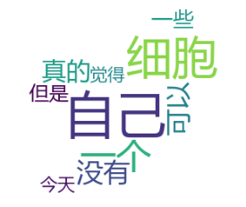

```python
# %load __main__.py
#引入结巴库
import  jieba
#词云库
from wordcloud import WordCloud
# python的可视化库，也是二级考试推荐的可视化库
import matplotlib.pyplot as plt
from PIL import Image  #处理图片的
 #矩阵 好像也是协助处理图片的
import numpy as np



#open 内置函数 不需要引用 直接使用
#开打文本文件和python 文件放到同一个目录，可直接引用不需要路径
f = open('test_1.txt', 'r' ,encoding='utf-8'  )

# 查看文件的编码格式
print('文件的编码格式:'+f.encoding)

#读取文件
txt = f.read()

#关闭文件，良好的习惯
f.close()


# 使用精确模式对文本进行分词
#  使用结巴库把文本拆分成一个个的词组
words = jieba.lcut(txt)


# 通过键值对的形式存储词语及其出现的次数
# 大括号表示 python的字典类型对应，
# 键值对 key:value1 ,类似java的map对象和list
counts = {}
#数组对象  用来接收需要传递给词云的内容
chiyun = []
for word in words:
     # == 1 单个词语不计算在内
    if  len(word) < 2 :
        continue
    else:
         # 遍历所有词语，每出现一次其对应的值加 1
        counts[word] = counts.get(word, 0) + 1

#将键值对转换成列表
items = list(counts.items())

# 根据词语出现的次数进行从大到小排序
items.sort(key=lambda x: x[1], reverse=True)


#列标题 format
print("{0:<5}{1:<8}{2:<5}".format('序号','词语', '频率'))


#需要显示的范围  10即显示前10个，0到9
for i in range(10):
    word, count = items[i]
    print("{0:<5}{1:<8}{2:>5}".format(i+1,word, count))
    chiyun.append(word)


 #print(chiyun)


#加载图片信息
maskph = np.array(Image.open('背景图.jpg'))


#join 函数 用斜杆拼接词组
text_cut  =  '/'.join(chiyun)
wordcloud = WordCloud(mask =maskph,  background_color='white',font_path = 'msyh.ttc', width=1000, height=860, margin=2).generate(text_cut)
# 显示图片
plt.imshow(wordcloud)
plt.axis('off')
plt.show()
```

### 4.2.2 wordcloud库可以用jpg作为遮罩，形成异形词云，进行美化

#### 以我之前的一篇文本为例，代码如下

```python
import jieba
import wordcloud
from imageio import imread

f = open(r'C:\Users\86158\Desktop\python\7\大学感受.txt', 'r', encoding='UTF-8')
txt = f.read()
f.close() #勿忘，否则会占用内存#

wordList = jieba.lcut(txt)
wcstr = ' '.join(wordList)

mask = imread(r'C:\Users\86158\Desktop\python\7\heart.png')

wc=wordcloud.WordCloud(
    'msyh.ttc', width=1440, height=1440,
    background_color='white', mask=mask)
#分别表示：字体、图片宽度、图片高度、背景颜色、遮罩使用的图片#

wcim=wc.generate(wcstr)
wcim.to_image().save(r'C:\Users\86158\Desktop\python\7\ciyun.png')
```

### 产生图片：

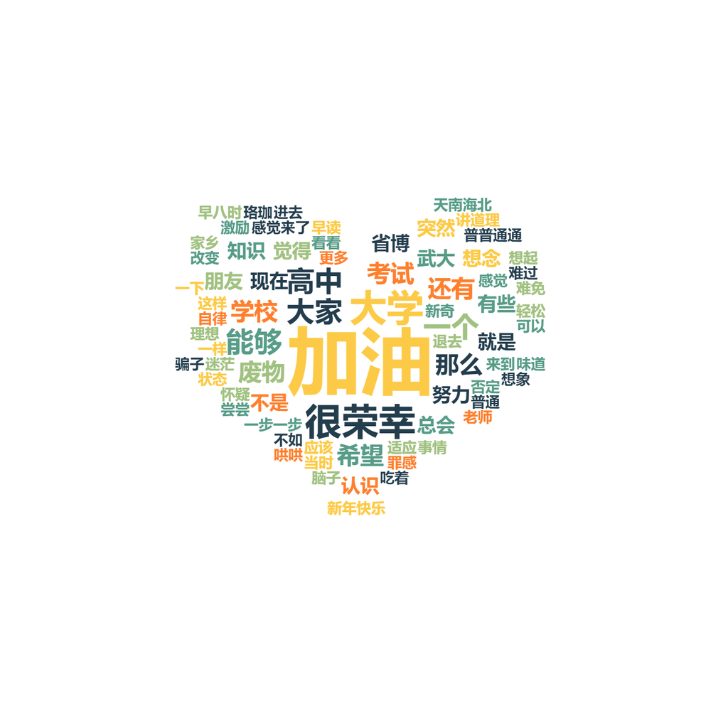

# 五、情感分析

GitHub源码地址贴在下面：

[大连理工中文情感分析](https://github.com/hidadeng/cnsenti)

## 5.1 安装中文情感分析包

最简单的方法是用CMD直接安装：输入pip install cnsenti。

### cnsenti库的API如下

```python
import cnsenti
```

```python
help(cnsenti)
```

```
Help on package cnsenti:

NAME
    cnsenti

PACKAGE CONTENTS
    emotion
    sentiment

FILE
    c:\users\hp\anaconda3\lib\site-packages\cnsenti\__init__.py
```

## 5.2 运行程序

### 5.2.1 我把某位朋友微博文本做了一个情感分析，代码如下

```python
# %load __main__.py
from cnsenti import Emotion
emotion=Emotion()
from cnsenti import Sentiment
senti=Sentiment()

import pandas as pd
data =pd.read_csv("7370755828.csv")

import numpy as np
col_1=data["微博正文"]
data_1=np.array(col_1)
with open('test_1.txt', 'w', encoding='utf-8') as f:
    f.write(data_1.__str__())
    f.close()

f=open("test_1.txt",encoding="utf-8")
text_text=f.read()
f.close()
result1=emotion.emotion_count(text_text)
result2=senti.sentiment_count(text_text)

print('emotion',result1)
print('sentiment',result2)
```

```
emotion {'words': 19428, 'sentences': 638, '好': 478, '乐': 107, '哀': 91, '怒': 3, '惧': 18, '恶': 246, '惊': 14}
sentiment {'words': 19428, 'sentences': 638, 'pos': 2873, 'neg': 564}
```

### 绘制柱状图代码如下

```python
# %load sentibarchart.py
import matplotlib
import matplotlib.pyplot as plt

# 中文乱码和坐标轴负号处理。
matplotlib.rc('font', family='SimHei', weight='bold')
plt.rcParams['axes.unicode_minus'] = False

#情绪数据。
emotion_name = ['好', '乐', '哀', '怒', '惧','恶','惊']

#填充数据
data = [478,107,91,3,18,246,14]

#绘图。
fig, ax = plt.subplots()
b = ax.barh(range(len(emotion_name)), data, color='#6699CC')

#为横向水平的柱图右侧添加数据标签。
for rect in b:
    w = rect.get_width()
    ax.text(w, rect.get_y()+rect.get_height()/2, '%d' %
            int(w), ha='left', va='center')

#设置Y轴纵坐标上的刻度线标签。
ax.set_yticks(range(len(emotion_name)))
ax.set_yticklabels(emotion_name)

#不要X横坐标上的label标签。
plt.xticks(())

plt.title('Sentiment Analysis', loc='center', fontsize='25',
          fontweight='bold', color='red')

plt.show()# 柱状图上的数值是对应情绪词汇在文本中出现的次数
```

### 效果图如下

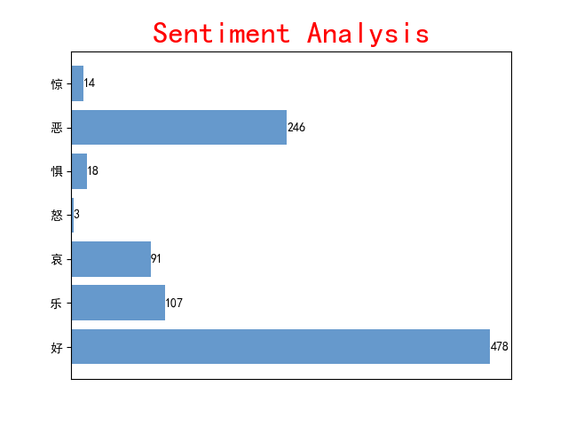

# 六、潜在迪利克雷分配

## 6.1 简介

### LDA（Latent Dirichlet Allocation）是一种**文档主题**生成模型

- 三层贝叶斯概率模型，包含**词**、**主题**和**文档**三层结构。
- **生成模型**认为一篇文章的主题词都是通过这样一个过程得到：从文章中以一定的概率选择了某个主题，并从这个主题中以一定概率选择了某个主题词。
- 文档到主题服从**多项式分布**，主题到词也服从**多项式分布**。

### LDA是一种非监督机器学习技术

可以用来识别大规模文档集（document collection）或语料库（corpus）中潜藏的主题信息。

- 采用了词袋（bag of words）的方法，将每一篇文档视为一个词频向量，从而将文本信息转化为了易于建模的数字信息。
- 但是词袋方法没有考虑词与词之间的顺序，这简化了问题的复杂性，同时也为模型的改进提供了契机。
- 每一篇文档代表了一些主题所构成的一个概率分布，而每一个主题又代表了很多单词所构成的一个概率分布。

### 多项分布的参数服从Dirichlet分布

Dirichlet分布是多项分布的参数的分布， 被认为是“分布上的分布”。

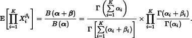

### LDA的名字由来

存在两个隐含的Dirichlet分布。

- 每篇文档对应一个不同的topic分布，服从多项分布
  - topic多项分布的参数服从一个Dirichlet分布。
- 每个topic下存在一个term的多项分布
  - term多项分布的参数服从一个Dirichlet分布。

## 6.2 参考文献

[*Latent dirichlet allocation*](https://www.jmlr.org/papers/volume3/blei03a/blei03a.pdf?TB_iframe=true&width=370.8&height=658.8)

| 关键词 | 中文释义 |
| --- | --- |
| text corpora | 文本语料 |
| three-level hierarchical Bayesian model | 三层贝叶斯概率模型 |
| variational methods | 变分方法 |
| Expectation–maximization algorithm | 最大期望算法 |
| empirical Bayes parameter estimation | 经验贝叶斯参数估计 |
| probabilistic LSI model(PLSI) | 潜在语义分析 |

# 七、 机器学习

## 7.1 机器学习概况

机器学习是一门多领域交叉学科，它涉及**概率论**、**统计学**、**计算机科学**、以及**软件工程**。机器学习是指一套工具或方法，任凭这套工具和方法，利用历史数据对机器进行“训练”进而“学习”到某种模式或规律，并建立预测未来结果的模型。

机器学习涉及两类学习方法，如图7-1所示。第一类是**有监督学习**，主要用于决策支持，它利用有标识的历史数据进行训练，以实现对新数据的标识的预测。第二类是**无监督学习**，主要用于知识发现，它在历史数据中发现隐藏的模式或内在结构。

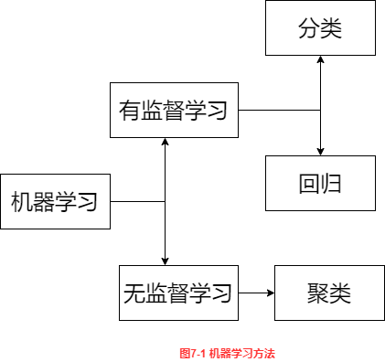

### 7.1.1 分类

分类技术预测的数据对象是离散值。经典分类方法如图7-2所示。

### 7.1.2 聚类

聚类算法用于在数据中寻找隐藏的模式或分组。经典聚类方法如图7-3所示。

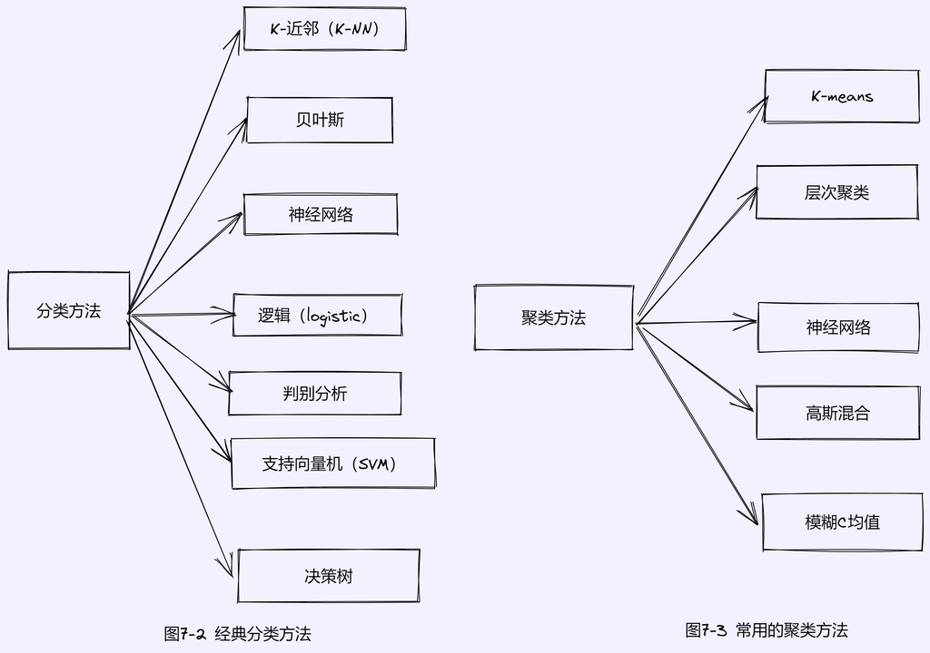

## 7.2 分类方法

### 7.2.1 K-近邻分类

K-NN通过计算每个训练样例到待分类样品的距离，取和待分类样品距离最近的k个训练样例，k个样品中哪个类别的训练样例占多数，则待分类元组就属于哪个类别。最近邻分类器把每个样例看作d维空间上的一个数据点，其中d是属性个数。给定一个测试样例，我们可以计算该测试样例与训练集中其他数据点的距离（邻近度）。

#### 方法特点：

- K-NN方法在类别决策时，只与极少量的相邻样本有关，因此，采用这种方法可以比较好地避免样本不平衡的问题。
- 对于类域的交叉或重叠较多的待分样本集来说，K-NN方法相较于其他方法更合适。
- K-NN算法适用于样本容留量较大的自动分类问题。

#### 不足：

该方法的不足之处是计算量较大，因为对每一个待分类的样本都要计算它到全体已知样本的距离，才能求得它的k个最近邻点。针对该不足，主要有以下两类改进方法：

1. 对于计算量大的问题，目前常用的解决方法是事先对已知样本点进行剪辑，去除对分类样本作用不大的样本。
2. 对样本进行组织、整理、分群、分层，尽可能将计算压缩到接近测试样本邻域的小范围内，避免盲目地与训练样本集中的每个样本进行距离计算。

### 7.2.2 贝叶斯分类

贝叶斯分类是一类分类算法的总称，这类算法均以贝叶斯定理（该定理会在《概率论与数理统计》中学到）为基础，故统称为贝叶斯分类。 在贝叶斯分类器中，朴素贝叶斯最为常用，下面是介绍朴素贝叶斯的原理。

#### 朴素贝叶斯

朴素贝叶斯分类是一种十分简单的算法，叫它朴素贝叶斯分类是因为这种方法的思想真的很朴素。朴素贝叶斯的思想是这样子的：对于给出的待分类项，求解在此项出现的条件下各个类别出现的概率，哪个最大，就认为此待分类项属于哪个类别。通俗来说，就好比你在街上看到一个黑人，我让你猜他是从哪来的，你十有八九猜非洲。为什么呢？因为黑人中非洲人的比率最高，当然也可能是美洲人或亚洲人，但在没有其他可用信息的条件下，我们会选择条件概率最大的类别，这就是朴素贝叶斯的思想基础。

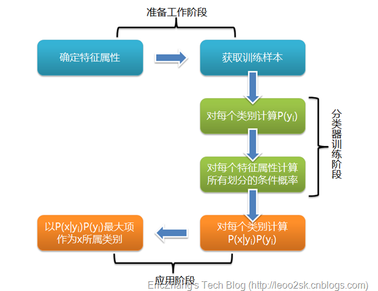

图7-4 朴素贝叶斯分类流程图

在许多场合，朴素贝叶斯分类可以与**决策树**和**神经网络分类算法**相媲美，其算法能运用到大型数据库中，且方法简单，**分类准确率高**，**速度快**。由于贝叶斯定理假设一个属性值对给定类的影响独立于其他属性值，而此假设在实际情况中经常是不成立的，因此其分类的准确率可能会下降。为此，就出现了许多降低独立性假设的贝叶斯分类算法，如**TAN(Tree Augmented Bayes Network)算法**、**贝叶斯网络分类器（Bayesian Network Classifier,BNC）**。

#### 朴素贝叶斯分类器一般具有以下特点：

- 简单、高效、~健壮~。面对孤立的噪声点，朴素贝叶斯分类器是~健壮~的，因为从数据中估计条件概率时，这些点被平均；另外，朴素贝叶斯分类器也可以处理属性值遗漏的问题。
- 相关属性可能会降低朴素贝叶斯分类器的性能，因为对这些属性，条件独立的属性已不成立。

## 7.3 深度学习

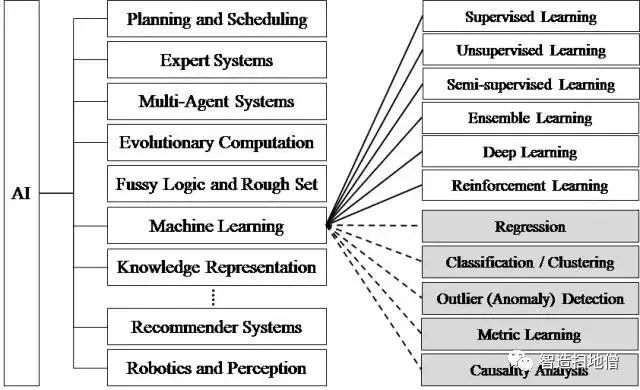

深度学习是机器学习中的一个新的领域，其动机在于建立、模拟人脑进行分析学习的**神经网络**，它模仿人脑的机制来解释数据，例如**图像**、**声音**和**文本**。深度学习的概念源于**人工神经网络**的研究，含多隐层的多层感知器就是一种深度学习结构。深度学习通过组合底层特征形成更加抽象的高层表示属性的**类别**或**特征**，以发现数据的分布式特征表示，可以简单地理解为神经网络的发展。

### 7.3.1 深度学习的原理

相较于传统的浅层学习，深度学习的不同在于：

1. 强调了模型结构的**深度**，通常有5层、6层，甚至10多层的隐层节点；
2. 明确突出了**特征学习**的重要性，也就是说，通过**逐层特征变换**，将样本在原空间的特征表示变换到一个新特征空间，从而使**分类**或**预测**更加容易。

与人工构造的方法相比，利用大数据来学习特征，更能够刻画数据的丰富内在信息。

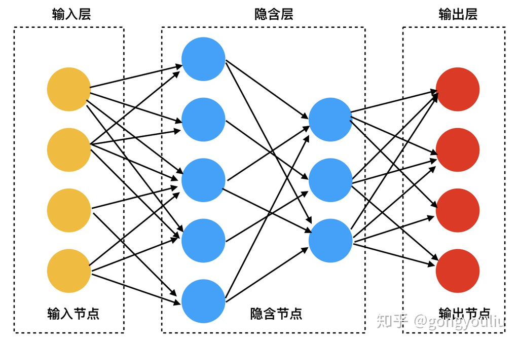

图7-6 深度学习网络结构示意图

## 学习资源

[吴恩达团队Tensorflow2.0实践系列课程第三课](https://www.bilibili.com/video/BV19E411g7d1?p=1&share_medium=android&share_plat=android&share_session_id=b66e69b2-c00e-4c61-ad31-6cf876626581&share_source=QQ&share_tag=s_i&timestamp=1633592423&unique_k=Xk04YJ)

[【斯坦福大学】CS229 机器学习](https://www.bilibili.com/video/BV1JE411w7Ub?from=search&seid=6508401937314067594&spm_id_from=333.337.0.0)

[基于机器学习的情感分析](https://chengjunwang.oschina.io/mybook/11-4-sentiment-classifier.html)

[《机器学习导论》](https://cicerocq.files.wordpress.com/2020/04/introductiontomachinelearning.pdf)

# 八、爬虫

## 学习资源

# 杂项

[股市点评：为啥大多数散户必定亏钱？——心理学层面的分析](https://program-think.blogspot.com/2015/07/China-Stock-Market-Psychology.html)

[为啥俺推荐 Python[5]：作为瑞士军刀的 Python——顺便分享俺整理的 Python 开源库](https://program-think.blogspot.com/2013/02/why-choose-python-5-tools.html)

[思维的误区：幸存者偏见——顺便推荐巴菲特最著名的演讲](https://program-think.blogspot.com/2015/05/Survivorship-Bias.html)